# KNN and LDA

Henry Mound

5/18/2020

## Setup

We will be using the clinical spectrum data set for K Nearest Neighbors (KNN) and Linear Discriminant Analysis (LDA) supervised learning. First, we will clean the data. This involves removing all of the NAs and only keeping relevant columns.

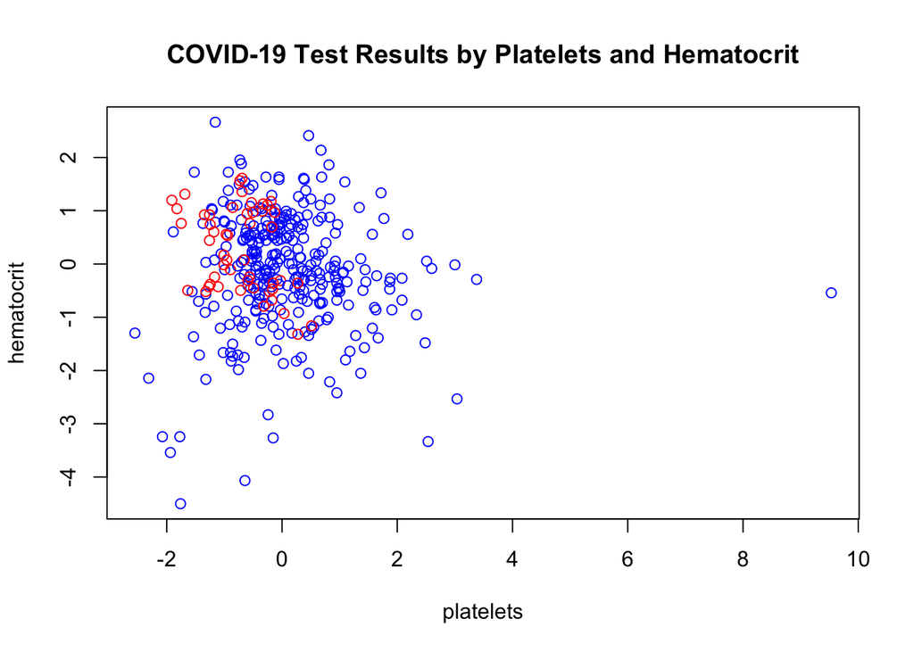

```r
# Remove all NAs and only keep relevant columns
clinical_spectrum_filtered <- clinical_spectrum[,c(1:39)]
clinical_spectrum_filtered <- clinical_spectrum_filtered[,-c(21, 28)]
clinical_spectrum_clean <- clinical_spectrum_filtered %>%
  na.omit()
# Now, convert test result to colors so we can plot.
# Red = positive COVID-19 test, Blue = negative
clinical_spectrum_cleanPlot <- clinical_spectrum_clean %>%
  mutate(test_result = ifelse(
    clinical_spectrum_clean$sars_cov_2_exam_result == 'negative',
    'Blue',
    'Red'))

# Let's take a look at how platelet levels and hematocrit effect
# test outcome
plotData <- as.data.frame(
  clinical_spectrum_cleanPlot[, c("test_result", "platelets", "hematocrit")])
plot( plotData[ , c(2, 3) ],
     col=plotData[ ,1 ],
     main = "COVID-19 Test Results by Platelets and Hematocrit")
```

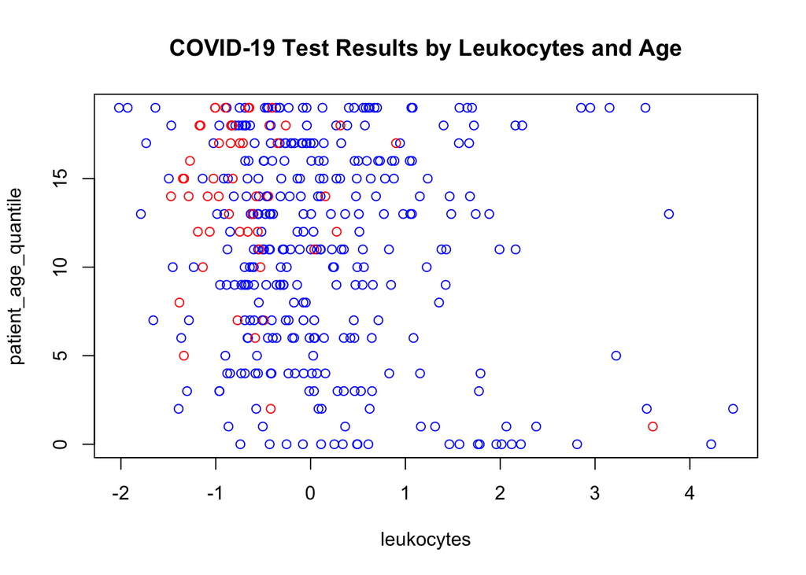

```r
# How about leukocytes and age?
plotData <- as.data.frame(
  clinical_spectrum_cleanPlot[, c("test_result", "leukocytes", "patient_age_quantile")])
plot( plotData[ , c(2, 3) ],
      col=plotData[ ,1 ],
     main = "COVID-19 Test Results by Leukocytes and Age")
```

But, how do these same four factors effect likelihood of being admitted to the ICU?

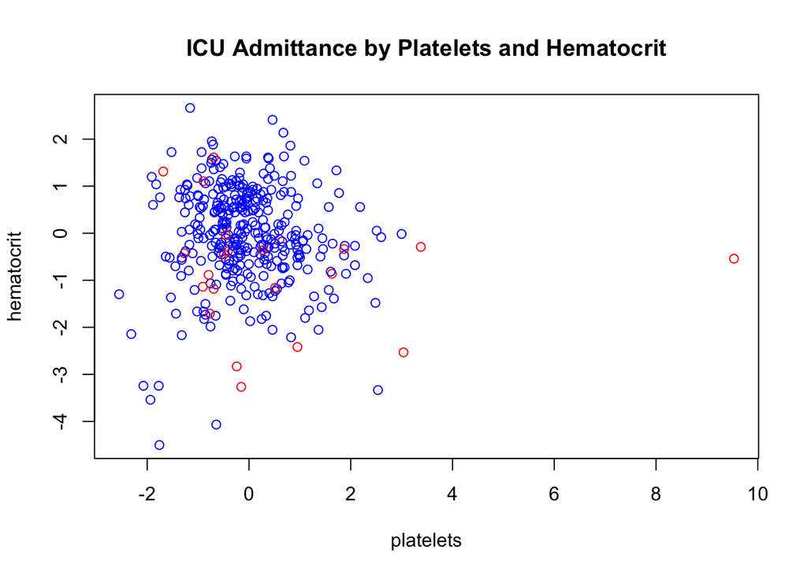

```r
# Now, convert icu result to colors so we can plot.
# Red = admitted, Blue = not
clinical_spectrum_cleanPlot <- clinical_spectrum_clean %>%
  mutate(icu_result = ifelse(
    clinical_spectrum_clean$patient_addmited_to_intensive_care_unit_1_yes_0_no == 'FALSE',
    'Blue',
    'Red'))

# Let's check out the save four variables for ICU admittance
plotData <- as.data.frame(
  clinical_spectrum_cleanPlot[, c("icu_result", "platelets", "hematocrit")])
plot( plotData[ , c(2, 3) ],
     col=plotData[ ,1 ],
     main = "ICU Admittance by Platelets and Hematocrit")
```

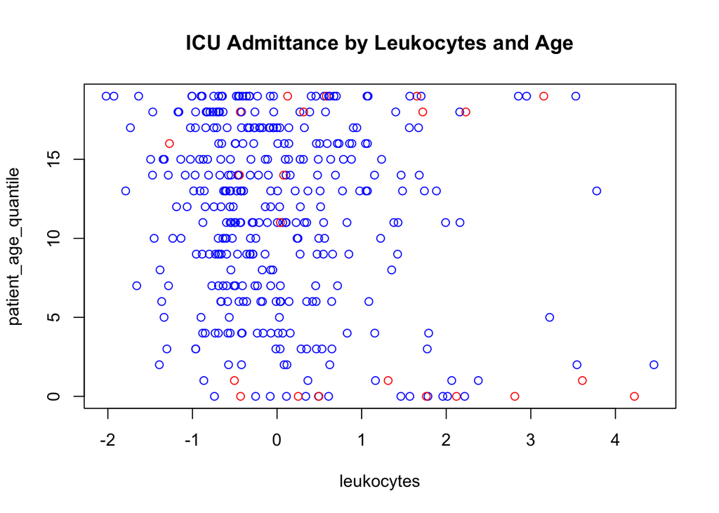

```r
plotData <- as.data.frame(
  clinical_spectrum_cleanPlot[, c("icu_result", "leukocytes", "patient_age_quantile")])
plot( plotData[ , c(2, 3) ],
      col=plotData[ ,1 ],
     main = "ICU Admittance by Leukocytes and Age")
```

## LDA

Now we will start implementing LDA.

```r
library(MASS)
# We create a funciton for calculating accuracy from tab results
accuracy <- function(x){sum(diag(x)/(sum(rowSums(x)))) * 100}

# Let's clean up the test results (A = negative, B = positive)
clinical_spectrum_clean <- clinical_spectrum_clean %>%
  mutate(test_result = ifelse(
    clinical_spectrum_clean$sars_cov_2_exam_result == 'negative',
    'A',
    'B'))

# Predicting covid test results from blood
clinical_spectrum_blood <- clinical_spectrum_clean[,c(7:20, 38)]
lda1 <- lda(test_result ~ .,
            data = clinical_spectrum_blood,
            CV = FALSE)
lda1Predict <- predict(lda1,
                       newdata=clinical_spectrum_blood
)
lda1tab <- table(lda1Predict$class, clinical_spectrum_blood$test_result)
accuracy(lda1tab)
```

```
## [1] 86.74033
```

Linear Discriminant Analysis implemented on this data set with all variables yields an 86.74% accuracy for predicting whether or not a patient has COVID-19. What about ICU rates?

```r
# Predicting ICU test results from blood
clinical_spectrum_icu <- clinical_spectrum_clean[,c(6:20)]
ldaICU <- lda(patient_addmited_to_intensive_care_unit_1_yes_0_no ~ .,
            data = clinical_spectrum_icu,
            CV = FALSE)
ldaICUPredict <- predict(ldaICU,
                       newdata=clinical_spectrum_icu
)
ldaICUtab <- table(ldaICUPredict$class, clinical_spectrum_icu$patient_addmited_to_intensive_care_unit_1_yes_0_no)
accuracy(ldaICUtab)
```

```
## [1] 93.92265
```

Linear Discriminant Analysis for predicting ICU admittance implemented on this data set with all variables yields an 93.92% accuracy. Interesting. Let’s plot to see what is going on.

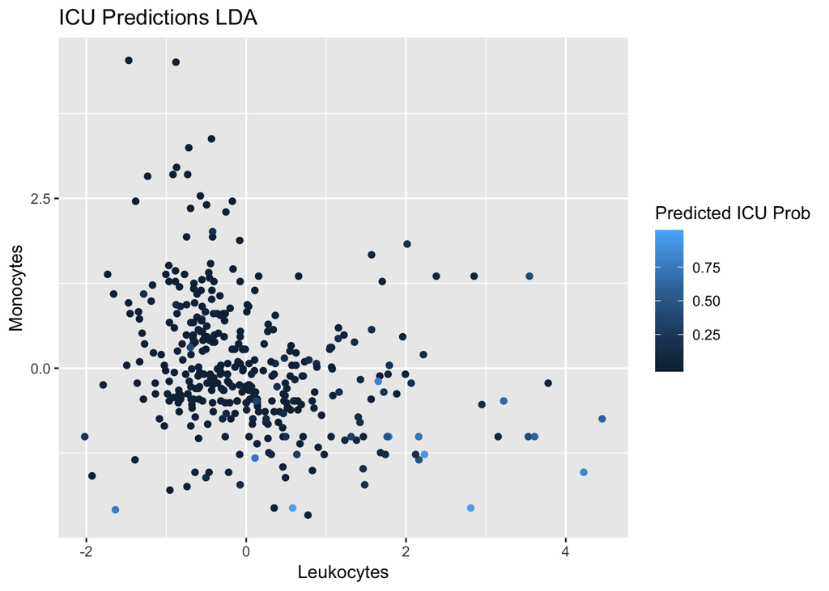

```r
# Now, we will plot
ldaICUPredictions1 <- ldaICUPredict$posterior[,2]
finalICUData1 <- data.frame(clinical_spectrum_icu, ldaICUPredictions1)
finalICUData1 %>%
  ggplot(aes(x = leukocytes,
             y = monocytes)) +
  geom_point(aes(color = ldaICUPredictions1)) +
  ggtitle("ICU Predictions LDA") +
  xlab("Leukocytes") +
  ylab("Monocytes") +
  labs(color = "Predicted ICU Prob")
```

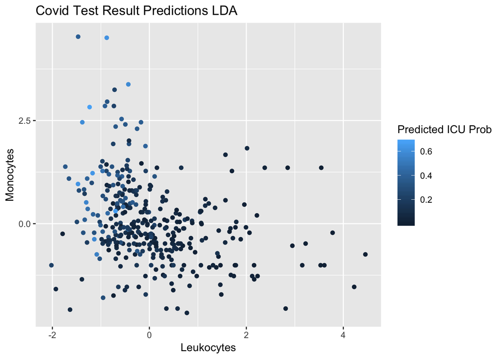

```r
ldaTestResultPredictions <- lda1Predict$posterior[,2]
finalICUData2 <- data.frame(clinical_spectrum_icu, ldaTestResultPredictions)
finalICUData2 %>%
  ggplot(aes(x = leukocytes,
             y = monocytes)) +
  geom_point(aes(color = ldaTestResultPredictions)) +
  ggtitle("Covid Test Result Predictions LDA") +
  xlab("Leukocytes") +
  ylab("Monocytes") +
  labs(color = "Predicted ICU Prob")
```

These graphs show interesting results.The predicted COVID-19 positive test results probability is higher when monocytes are higher and leukocytes are lower (top-left), wheras the predicted ICU probability is higher in the opposite conditions, when leukocyte levels are higher and monocytes are lover (bottom-right).

# Now we will implement KNN

```r
library(class) # For KNN
set.seed(2)
# We will split the data into 75% training, 25% testing
train_ind <- sample(seq_len(nrow(clinical_spectrum_clean[,c(6:20)])),
                    size = floor(0.75 * nrow(clinical_spectrum_clean[,c(6:20)])))
trainICU <- clinical_spectrum_clean[,c(6:20)][train_ind, ]
testICU <- clinical_spectrum_clean[,c(6:20)][-train_ind, ]
# We will predict for ICU admittance first
pred <- knn(train = trainICU,
            test = testICU,
            cl = trainICU$patient_addmited_to_intensive_care_unit_1_yes_0_no,
            k = 1)
tab <- table(pred, testICU$patient_addmited_to_intensive_care_unit_1_yes_0_no)
accuracy(tab)
```

```
## [1] 92.30769
```

Our KNN implementation yields a 92.31% accuracy on the test data when predicting for ICU admittance, compared to 93.92% using LDA.

Let’s try KNN to predict COVID-19 test results.

```r
# KNN for test results
clinical_spectrum_clean <- clinical_spectrum_clean %>%
  mutate(test_result = ifelse(
    clinical_spectrum_clean$sars_cov_2_exam_result == 'negative',
    TRUE,
    FALSE))
train_ind1 <- sample(seq_len(nrow(clinical_spectrum_clean[,c(7:20, 38)])),
                    size = floor(0.75 * nrow(clinical_spectrum_clean[,c(7:20, 38)])))
trainCovid <- clinical_spectrum_clean[,c(7:20, 38)][train_ind1, ]
testCovid <- clinical_spectrum_clean[,c(7:20, 38)][-train_ind1, ]

pred <- knn(train = trainCovid,
            test = testCovid,
            cl = trainCovid$test_result,
            k = 1)
tab1 <- table(pred, testCovid$test_result)
accuracy(tab1)
```

```
## [1] 86.81319
```

In both cases, KNN performs very comparably to LDA.